# Hypothesis Testing

Adam

May 27, 2018

## Hypothsis testing

In empirical research, we test theories. A good theory, is one that testable predictions. To test prediction, the null hypothesis significance test (**NHST**) is the most prevalent statistical tool for testing such predictions.

### Setting up a statistical hypothesis.

e.g.test whether drug to reduce a motivation for food. Compare rats in a treatment group to a control group. Our rats that get the drug will be less drink less sugar, perhaps and consequenly will spend more time lever pressing for that drug.

With an NHSTs we calculate the probability of an effect of a certain size, or larger being observed if there was no true effect. This is done by testing a null hypothesis ($H_0$) rather than the hypothis of interest, ($H_1$). The null hyphothis, is the hypothisis that there is no effect.

A NHST calculates the probabilty of obtaining an event a differnce in motivation for sugar, n. In our example, we determine the probability obtaining a our measure motivation if our true populaiton differnce difference was 0 lever presses. This probability is the signifnace probability, or $p$

If p, is small enough, than we might deem that resonable to reject the null hyphthesis, and state that the treatment is effective. If p is large, thatn we coudl say that our result could have been eaisly obtained by chance if $H_0$ is true, that is our treamtent was not effective in reducting the motivation for sugar water. In this case our test indicatress a fialure to reject the null hypothesis.

Thefore, there are 2 potential outcomes, rejecting, or failing to rejecting, or failing to reject the null hypothesis. This is the basis of NHSTs

There are some subtle disctions here, lets review the main points

1. A $H_0$ is set up
2. the probability ($p$) of obtaining the observed statstic or one more exterme if $H_0$ is tru eis calculatteecd
3. if $p$ is small, we reject the H_0 and if p is large, the we fail to recject $H_0$

The reaons we set up a null hypothisis is a philosphical. Failing to reject the null does not mean we found that there is no effect, but rather that our measure was inconclusive. We cannot show an absence of an effect, so we say that we have failed to reject the null.

Despite that the NHST is very poplular, it is also very demanidng. it needs to be: 1. the $p$ value is caluclated not in relation the hypohothis of interest but for the null hypotheis. 2. **A *p* value is conditional probability, specificallly it is the probability of a result as extreme or more extreme than the one observed when $H_0$ is true.** It is *not* the the probability of $H_0$ being true (an unconditional probability).

OK, so we reject H0 when $p$ is small, but what is a small p?

## Statsical significance, confidnece and alpha

NHSTs work only if we set a signifincacne cirtiron, denoted by $\alpha$. is set prior to the test. Otherwise we can always say, well, thats closes enough, or myaybe this will work this time. What $\alpha$ is often specfict to various fields. Although in an ideal world, $\alpha$ should be set for each test, realsitcally there is no way of know if the value of alpha was fixed prior to the test. so to be fair, this has to be set before

For many discplices a common $\alpha$ level is set $\alpha = 0.05$. We say that when $p<0.05$ that statstical signifcance is declared.

## Calculating p for one-sided and two sided tests

In order to construct significance test, at least 3 components are required.

1. A null hypothesis.
2. An $\alpha$ level.
3. A way of calculating $p$

If the data is sampled from a known probability distribution, the $p$ can be calculated exactly. Otherwise, it we estimate $p$

When the distribution is no known,test statistic are constructed so they follow a familiar distribution. The central limit theorem, which shows that the sampling distribution can be normally distributed, provides a justification for many approximations.

# A one sample z-test

*A basic form of NHST when varaince of distribution is known.* \

In theory, we cannot know the population paramters unless we recorded them from each memeber of the population. In practice we can come close enought in cases where we have a lot of data, e.g. BMI, or IQ. So in practice this can be true.

Say that it is well know rats will spend on average of 12.5 min out of 30 min sesssion, lever pressing for given concentration of sugar water over a fixed duraiton of time. \

If we are testing an appetite suppressing durg, our $H_0$ that the drug has no effect:
$$H_0: \mu = 12.5\\ H_1: \mu \neq 12.5\\$$

Lets say that we evaluated a sample of $n=16$ rats, which were given the appetite suppressing drug. We found that these rats spend 9.5 min lever pressing for the sugar water over fixed session duration.

Lets also say that the variance for time spent lever pressing for rats is 2 min. If the distrubiton of the time spent lever pressing is *normall distributed*, we can obtain obtain a test z-statistic, or z-score.

So in this
$$\frac{(\hat{\mu}-\mu_0)}{\sigma_{\hat{\mu}}} = \frac{(9.5-12.5)}{2} = -1.5$$

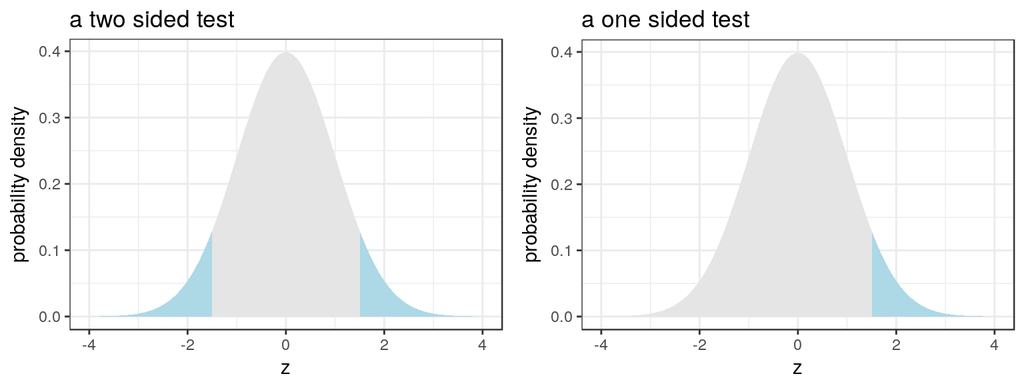

```r
pnorm(1.65) #our p value is
```

```
## [1] 0.9505285
```

```r
1 - pnorm(1.5)
```

```
## [1] 0.0668072
```

for a one sided test. while for a two sided test we sum the the tail probabilites, which woudl be 0.134. Depending on our chosen $\alpha$ we can reject or fail to reject the null. This can also be dependnent on whehter the test is one or two-sided.

Howevre, although directional tests produces smaller p-values than non-directional tests it usually recommened against.  
For tests statistics with symmetrical distribution the observed p value for a one sided directional equivalent will be half of the of the equivalent. However:

1. What if there is an effect in opposite two our prediction?
2. We need to choose our $\alpha$ in advance

on-sided tests are the fore usually avoided.

## t-test

Since we don’t usually know the variance of the normal distribution from which we are drawing our sample we use the t-distribution for our significance test. The t distribution is better for small ns, but it beings to look like the z distribution as the $n$ increases

#### one sample t-test

An NHST for a single sample constructed using same estimate of $\sigma$. if H_0 is true the statstic is:

$t = \hat{\mu} - \mu_0$

### Independent t-test

The independent t-test is is the NHST of difference between the means, of two *independent normal samples*, with unknown but *equal $\sigma$*

If the null hypothies true (no difference between the means) $H_0: \mu_1 - \mu_2$ = 0, where the alternate hypothisis is $H_A: \mu_1 \neq \mu_2$

The t-statistic takes the form of

$$\frac{\hat{\mu_1} - \hat{\mu_1} - \sigma_0}{\hat{\sigma_{\hat{\mu_1}-\hat{\mu_2}}}} = \\ \frac{\hat{\mu_1} - \hat{\mu_2} - \sigma_0}{\hat{\sigma}_{pooled} \sqrt{1/n_1 + 1/n_2}}$$

This distribution has a df of N-2 wher eN is the total samle size

if the equal variance assumption is not met than the Welch-Satterthwaite correction can be employed, R does this by default